# R Practical 01 - Introduction

Christoforos Nikolaou

2024-11-08

```r
setwd("C:/Users/chris/Dropbox/github/MolBioMedClass/RMarkdown")
```

## R Practical

In this practical class we will try to put into practice a number of statistical and bioinformatics analyses we have already discussed and presented.

### Part 0. Basics

We will be using this space to present elements of the R language and technical issues.

### Part 1. Statistics

We will use this space to discuss concepts of statistics

#### 1.1 Comparing means of distributions with t-test

We will compare the GC% of the yeast genes vs yeast non-coding sequences. We will first load them in R like this:

```r
gcGenes<-read.delim("C:/Users/chris/Dropbox/github/MolBioMedClass/Datasets/SCgenes_gcContent.tsv", header=T, sep="\t")
gcRegSeq<-read.delim("C:/Users/chris/Dropbox/github/MolBioMedClass/Datasets/SCRegSeq_gcContent.tsv", header=T, sep="\t")
```

and inspect the dataframe structures

```r
str(gcGenes)
```

```
## 'data.frame':    6692 obs. of  3 variables:
##  $ SeqName: chr  "YAL012W" "YAL069W" "YAL068W-A" "YAL068C" ...
##  $ GC     : num  0.487 0.435 0.353 0.496 0.412 ...
##  $ Length : int  1185 315 255 363 228 1782 309 387 381 381 ...
```

```r
head(gcRegSeq)
```

```
##   SeqName        GC Length
## 1 RegSeq1 0.3689840   1309
## 2 RegSeq2 0.3665768    371
## 3 RegSeq3 0.3106996   1458
## 4 RegSeq4 0.3534768   1208
## 5 RegSeq5 0.3525480   1197
## 6 RegSeq6 0.3319805   1232
```

Next, we may plot the distributions of GC% values in the form of boxplots.

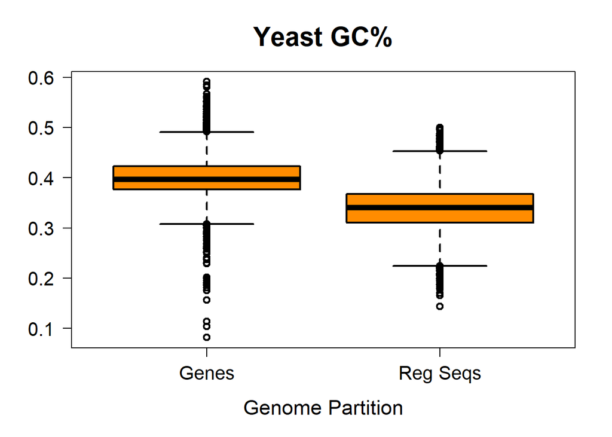

```r
boxplot(gcGenes$GC, gcRegSeq$GC, lwd=2, col="dark orange", names=c("Genes", "Reg Seqs"), main="Yeast GC%", las=1, xlab="Genome Partition", cex.main=1.8, cex.axis=1.3, cex.lab=1.4)
```

And, as a final step, we will assess the differences in the distributions’ means by applying a t-test.

```r
t.test(gcGenes$GC, gcRegSeq$GC)
```

```
##
##  Welch Two Sample t-test
##
## data:  gcGenes$GC and gcRegSeq$GC
## t = 81.663, df = 12396, p-value < 2.2e-16
## alternative hypothesis: true difference in means is not equal to 0
## 95 percent confidence interval:
##  0.06097173 0.06397072
## sample estimates:
## mean of x mean of y
## 0.4010005 0.3385293
```

### Part 2. Modeling

We will be using this space to present problems that require modeling and ways to solve them using R.

#### 2.1 The hot-hand fallacy (or not)

An actual player’s shots for a 187 consecutive shots

```r
real<-read.table("C:/Users/chris/Dropbox/github/MolBioMedClass/Datasets/bballshots.txt")[,1]
```

Let’s count her shooting success rate

```r
length(which(real==1))/length(real)
```

```
## [1] 0.5080214
```

And now let’s see how great are her streaks of consecutive successful shots

```r
realRuns<-rle(real)
realRuns
```

```
## Run Length Encoding
##   lengths: int [1:77] 1 7 1 1 2 1 5 3 3 1 ...
##   values : int [1:77] 1 0 1 0 1 0 1 0 1 0 ...
```

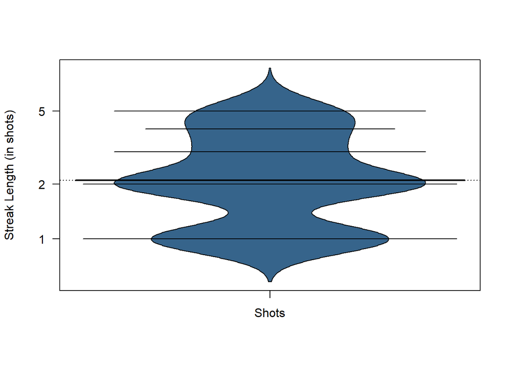

```r
library(beanplot)
rstreaks<-which(unlist(realRuns[2])==1)
rstreaklengths<-unlist(realRuns[1])[rstreaks]
beanplot(rstreaklengths, col="steelblue4", ylab="Streak Length (in shots)", names="Shots", las=1, log="y")
```

```r
shots<-rbinom(187, 1, p=0.508)
shots
```

```
##   [1] 0 0 1 1 1 1 1 1 1 1 0 1 1 1 1 1 0 0 0 1 1 0 1 0 0 0 1 0 0 0 1 1 0 0 0 1 1
##  [38] 1 1 1 1 1 0 1 1 1 0 1 1 0 1 0 1 0 1 0 0 1 0 0 1 1 1 0 0 0 0 0 0 1 1 1 0 0
##  [75] 0 0 0 1 1 1 0 1 0 1 0 1 1 0 1 1 1 1 1 0 0 0 0 1 1 1 0 1 0 1 1 0 1 0 1 1 1
## [112] 1 1 0 0 1 0 1 1 1 1 1 0 0 0 0 1 0 1 0 0 1 0 1 0 1 0 1 0 0 1 1 0 0 1 0 0 0
## [149] 1 1 1 1 0 0 1 1 1 1 0 1 1 0 0 0 1 0 1 1 1 0 1 1 0 0 1 1 0 1 0 0 0 1 0 0 0
## [186] 1 0
```

```r
rle(shots)
```

```
## Run Length Encoding
##   lengths: int [1:91] 2 8 1 5 3 2 1 1 3 1 ...
##   values : int [1:91] 0 1 0 1 0 1 0 1 0 1 ...
```

```r
shotRuns<-rle(shots)
shotRuns
```

```
## Run Length Encoding
##   lengths: int [1:91] 2 8 1 5 3 2 1 1 3 1 ...
##   values : int [1:91] 0 1 0 1 0 1 0 1 0 1 ...
```

```r
streaks<-which(unlist(shotRuns[2])==1)
streaklengths<-unlist(shotRuns[1])[streaks]
```

And now let’s compare the real with the simulated runs

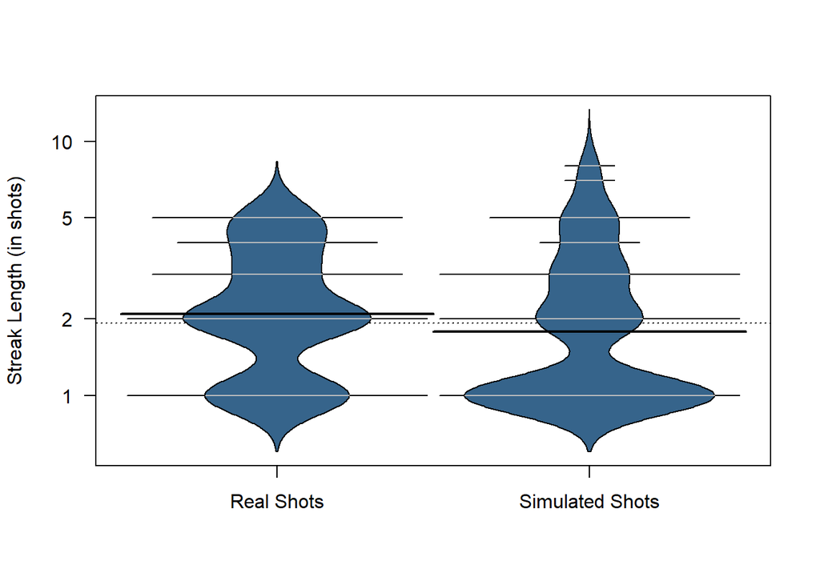

```r
beanplot(rstreaklengths, streaklengths, col=c("steelblue4", "grey"), ylab="Streak Length (in shots)", log="y", names=c("Real Shots", "Simulated Shots"), las=1)
```